# Trabajo Nº4 Series de tiempo

Juan Pablo Jaramillo Castrillón

4/12/2020

#### 1) Utilice la función locate.outlaiers() de la librería tsoutliers sobre el modelo que Ud encontro más adecuado para modelar la serie del 2Do trabajo. En caso de que no detecte ninguno (outliers) considere alguna otra de las 4 series.

Buscando una base de datos de trabajos anteriores, con una inspección previa la base de datos que corresponde a la producción de tabaco en los estados unidos es la que mas se aproxima para estudiar la detección de outliers. Observemos la serie.

[interactive chart not shown]

No es estacionaria entonces diferenciamos la serie.

[interactive chart not shown]

Observamos tambien que su varianza no es constantes entonces, hacemos una transformación log a la serie

[interactive chart not shown]

```
## Series: tabac_log
## ARIMA(0,1,1) with drift
##
## Coefficients:
##           ma1   drift
##       -0.6889  0.0143
## s.e.   0.0687  0.0048
##
## sigma^2 estimated as 0.02656:  log likelihood=45.35
## AIC=-84.7   AICc=-84.48   BIC=-76.52
```

luego ajustamos un modelo por medio de una auto.Arima(), que arroja ordenes p=0,d=1 y q= 1 con sus coeficientes estimados significativos(ARIMA(0,1,1)), hacemos un chequeo de errores de pronosticos.

|  | ME | RMSE | MAE | MPE | MAPE | MASE | ACF1 |
| --- | --- | --- | --- | --- | --- | --- | --- |
| Training set | 0.0016715 | 0.1608143 | 0.1181176 | 0.0160792 | 1.703397 | 0.8661703 | -0.0082688 |

Los errores son relativamente bajos, el MAPE es de 1.70%. chequiemos el modelo

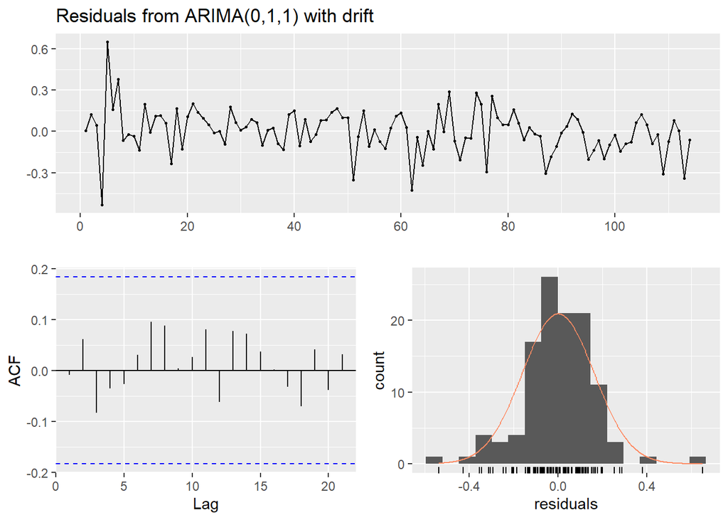

```
##
##  Ljung-Box test
##
## data:  Residuals from ARIMA(0,1,1) with drift
## Q* = 3.8144, df = 8, p-value = 0.8735
##
## Model df: 2.   Total lags used: 10
```

Segun la prueba Ljung-Box, los residuales es ruido blanco. por el momento todo esta en orden, luego analicemos los outliers utilizando la función locate.outliers.

#### a) Que tipo de outliers: AO, IO, LC, TS detecta en el conjunto de datos analizado?.

|  | type | ind | coefhat | tstat |
| --- | --- | --- | --- | --- |
| 1 | AO | 4 | -0.6927707 | -5.444115 |
| 3 | LS | 5 | 0.4823038 | 4.804995 |

Se encuentran dos tipos de outliers, el primero es AO que es un tipo de evento que afecta a la serie de tiempo en solamente en un periodo de tiempo, es un valor inesperado en el tiempo 4 a un nivel bajo. también un LS, este afecta a varias observaciones y tiene un efecto permanente

#### b) Explique el efecto sobre la serie de cada uno de los tipos de outliers que Ud detecta en la misma.

[interactive chart not shown]

La serie es afectada por dos outliers tipo AO y SL, observemos el mas crucial que es el SL un cambio en nivel que afecta a una serie en ese periodo y sigue permanente. como se observa en el año 5 hasta que termina la serie. también el AO que es aditivo, que solo afecta en ese preciso instante( observación 4) pero retorna al nivel siguiendo el comportamiento histórico de la serie.